# Intro to Data Science - HW 3

##### Copyright Jeffrey Stanton, Jeffrey Saltz, and Jasmina Tacheva

```r
# Enter your name here: Ryan Brown
```

### Attribution statement: (choose only one and delete the rest)

```r
# 1. I did this homework by myself, with help from the book and the professor.
```

### Reminders of things to practice from last week:

Make a data frame data.frame( )  
Row index of max/min which.max( ) which.min( )  
Sort value or order rows sort( ) order( )  
Descriptive statistics mean( ) sum( ) max( )  
Conditional statement if (condition) “true stuff” else “false stuff”

### This Week:

Often, when you get a dataset, it is not in the format you want. You can (and should) use code to refine the dataset to become more useful. As Chapter 6 of Introduction to Data Science mentions, this is called “data munging.” In this homework, you will read in a dataset from the web and work on it (in a data frame) to improve its usefulness.

## Part 1: Use read_csv( ) to read a CSV file from the web into a data frame:

1. Use R code to read directly from a URL on the web. Store the dataset into a new dataframe, called dfComps.  
   The URL is:  
   “https://intro-datascience.s3.us-east-2.amazonaws.com/companies1.csv”  
   **Hint:** use read_csv( ), not read.csv( ). This is from the **tidyverse package**. Check the help to compare them.

```r
library(tidyverse)
dfComps <- read.csv("https://intro-datascience.s3.us-east-2.amazonaws.com/companies1.csv")
```

## Part 2: Create a new data frame that only contains companies with a homepage URL:

5. Use **subsetting** to create a new dataframe that contains only the companies with homepage URLs (store that dataframe in **urlComps**).

```r
urlComps <- dfComps [which(dfComps$homepage_url !='NA'),]
```

4. How many companies are missing a homepage URL?

```r
dim(urlComps)
```

```
## [1] 47758    18
```

## Part 3: Analyze the numeric variables in the dataframe.

7. How many **numeric variables** does the dataframe have? You can figure that out by looking at the output of **str(urlComps)**.
8. What is the average number of funding rounds for the companies in **urlComps**?

```r
mean(urlComps$funding_rounds)
```

```
## [1] 1.688576
```

1. What year was the oldest company in the dataframe founded?  
   **Hint:** If you get a value of “NA,” most likely there are missing values in this variable which preclude R from properly calculating the min & max values. You can ignore NAs with basic math calculations. For example, instead of running mean(urlComps$founded_year), something like this will work for determining the average (note that this question needs to use a different function than ‘mean’.

```r
min(urlComps$founded_year, na.rm=TRUE)
```

```
## [1] 1900
```

## Part 4: Use string operations to clean the data.

11. The **permalink variable** in **urlComps** contains the name of each company but the names are currently preceded by the prefix “/organization/”. We can use str_replace() in tidyverse or gsub() to clean the values of this variable:

```r
urlComps$CompName <- str_replace(urlComps$permalink, "/organization/","")
```

12. Can you identify another variable which should be numeric but is currently coded as character? Use the as.numeric() function to add a new variable to **urlComps** which contains the values from the char variable as numbers. Do you notice anything about the number of NA values in this new column compared to the original “char” one?

```r
class(urlComps$funding_total_usd)
```

```
## [1] "character"
```

```r
urlComps$FundingUSD  <-gsub("","",urlComps$funding_total_usd)
```

13. To ensure the char values are converted correctly, we first need to remove the spaces between the digits in the variable. Check if this works, and explain what it is doing:

```r
library(stringi)
urlComps$FundingUSD <- stri_replace_all_charclass(urlComps$FundingUSD,"\\p{WHITE_SPACE}", "")

#this is trying to trim the white spaces in the data
```

[output not shown]

N. You are now ready to convert **urlComps$funding_new** to numeric using as.numeric().

Calculate the average funding amount for **urlComps**. If you get “NA,” try using the **na.rm=TRUE** argument from problem I.

```r
urlComps$FundingUSD <- as.numeric(urlComps$FundingUSD)
mean(urlComps$FundingUSD, na.rm=TRUE)
```

```
## [1] 17820092
```

```r
observations <- sample(urlComps$funding_rounds, size=7)
```

Take the mean of those observations

```r
mean(observations)
```

```
## [1] 1.857143
```

Do the two steps (sampling and taking the mean) in one line of code

```r
Observations <- mean(sample(urlComps$funding_rounds, size=7))
```

Explain why the two means are (or might be) different

Use the replicate( ) function to repeat your sampling of three observations of urlComps$funding_rounds observations five times. The first argument to replicate( ) is the number of repeats you want. The second argument is the little chunk of code you want repeated.

```r
#Mine were the same.

replicate(5,mean(sample(urlComps$funding_rounds, size=3, replace=F)))
```

```
## [1] 1.000000 1.666667 2.333333 2.000000 2.333333
```

Rerun your replication, this time doing 20 replications and storing the output of replicate() in a variable called **values**.

```r
Values <- replicate(20,mean(sample(urlComps$funding_rounds, size=3, replace=F)))
```

Generate a **histogram** of the means stored in **values**.

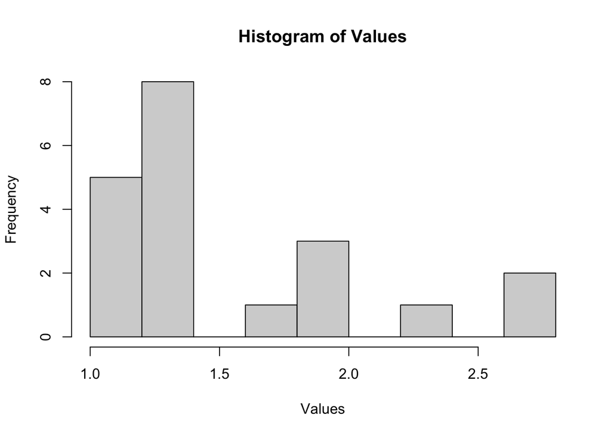

```r
hist(Values)
```

Rerun your replication, this time doing 1000 replications and storing the output of replicate() in a variable called **values**, and then generate a histogram of **values**.

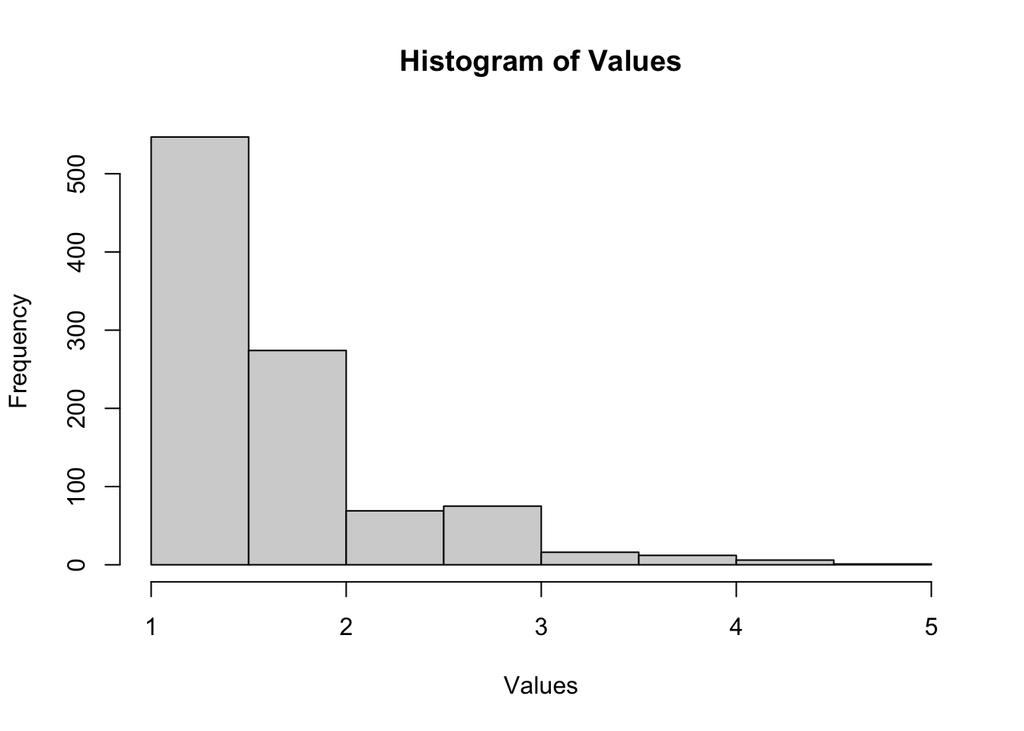

```r
Values <- replicate(1000,mean(sample(urlComps$funding_rounds, size=3, replace=F)))
hist(Values)
```

Repeat the replicated sampling, but this time, raise your sample size from 3 to 22. How does that affect your histogram? Explain in a comment.

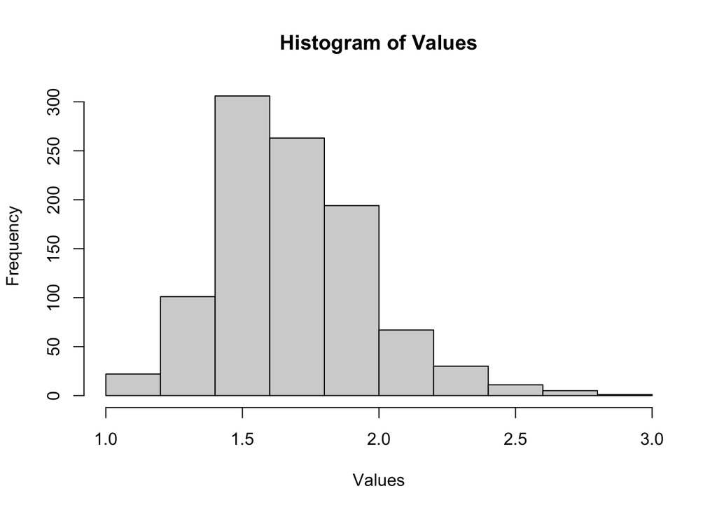

```r
Values <- replicate(1000,mean(sample(urlComps$funding_rounds, size=22, replace=F)))
hist(Values)
```

Explain in a comment below, the last three histograms, why do they look different?

```r
#When we increased the sample size, we can see that the distribution became more normally distributed.
```